# 01 Complete script

Guillermo Bustos-Pérez

26/11/2021

# Multiple approaches to predict flake mass

- Guillermo Bustos-Pérez $^{(1,2)}$
- Javier Baena Preysler $^{(1)}$

$^{1}$ Departamento de Prehistoria y Arqueología, Universidad Autónoma de Madrid, Madrid, Spain  
$^{2}$ Corresponding author at: guillermo.bustos@estudiante.uam.es | guillermo.willbustos@gmail.com

## Abstract

Predicting original flake mass is a major goal of lithic analysis. Predicting original flake mass allows to make estimations of remaining mass, lost mass, etc. All these measures relate to the organization of lithic technology by past societies. The present work tests three different models to predict log of flake mass: Multiple Linear Regression, Random Forest regression and Artificial Neuronal Network (ANN). Estimations of flake mass are performed using remaining features of flakes from an experimental assemblage. This assemblage has been obtained by the expansion of a previous dataset by the inclusion of bigger flakes, allowing to account for the effects of sample size and value distribution. Correlation results show a large/strong relation between predictions and real outcome (r2 = 0.78 in the best case). Comparison of models allows to gain insights into variable importance for predicting flake mass. Results also show that (for the present dataset) multiple linear regression still stands as the best method for predicting log of flake weight. Additionally, transformation of predicted values from the multiple linear regression and true values to the linear scale reinforces the linear correlation above the 0.8 threshold.

**Key words:** lithic technology; experimental archaeology; flake weight; Machine Learning; Deep Learning

## Introduction

“Curated” is a key concept for the analysis of lithic technological organization (Andrefsky, 2009; Binford, 1979; Nelson, 1991; Spry and Stern, 2016). Initially “curated” was defined to encompass a series of behavioral patterns related to provisioning strategies (Binford, 1979, 1973). Further authors included tool transport, utilization in a wide range of tasks, anticipated production, hafting and recycling (after original tool had been discarded) into the behavioral adaptive strategies that defined a curation.

## 01 Installing packages

The following code provides the list of packages employed in the analysis, checks if they are missing and installs the missing ones. This is set to meet reproducibility standards for machine learning (Heil et al., 2021).

```r
list.of.packages <- c("tidyverse", "lattice", "caret", "neuralnet", "ranger", "NeuralNetTools")

new.packages <- list.of.packages[!(list.of.packages %in%
                                     installed.packages()[,"Package"])]

if(length(new.packages)) install.packages(new.packages)
```

After this we can load the packages to perform model training and analysis. Additionally in this markdown we are going to use package knitr to show a nice output of tables. The present study makes extensive use of tidyverse (Wickham et al., 2019) and caret (Kuhn, 2008) for the treatment of data and training of models.

```r
list.of.packages <- c("tidyverse", "lattice", "caret", "neuralnet", "ranger", "knitr")

lapply(list.of.packages, library, character.only = TRUE)
```

[output not shown]

## 02 Loading and describing the data

Sample for analysis is composed of 500 experimentally knapped flakes using a variety of hard hammerd (quartzite, quartz, sandstone). Flakes belong to 30 knapping sequences where a wide variety of knapping methods were employed —hierarchical (Levallois and Hierarchical Discoid), bifacial (Discoid), and unipolar— to generate the experimental sample, ensuring a wide range of morphologies. This is an expansion of a previous dataset employed for similar purposes (Bustos-Pérez and Baena, 2021) which allows to expand the range of dimensions and mass of the assemblage.

```r
# Load the data
Reg_Data <- read.csv("Data/Flake Mass v02 Eng.csv")
```

```r
kable(Reg_Data[1:10,])
```

| Length | Width | MeanThick | Max_Thick | Weight | Surface.Plat | Platfom_Depth | Cortex | No_Scars | Termination_type | EPA | Log_Weight | Log_Max_Thick | Log_Plat | Log_Plat_De |
| --- | --- | --- | --- | --- | --- | --- | --- | --- | --- | --- | --- | --- | --- | --- |
| 51.3 | 29.8 | 10.066667 | 13.1 | 17.83 | 83.585 | 7.3 | 5 | 4 | Feather | 51 | 1.2511513 | 1.1172713 | 1.922128 | 0.8633229 |
| 49.1 | 30.0 | 8.566667 | 9.7 | 13.33 | 90.480 | 7.8 | 5 | 3 | Feather | 70 | 1.1248301 | 0.9867717 | 1.956553 | 0.8920946 |
| 30.8 | 43.8 | 11.566667 | 16.8 | 20.33 | 40.500 | 3.6 | 3 | 2 | Feather | 35 | 1.3081374 | 1.2253093 | 1.607455 | 0.5563025 |
| 30.2 | 19.6 | 5.500000 | 6.7 | 3.98 | 59.670 | 5.1 | 5 | 3 | Feather | 66 | 0.5998831 | 0.8260748 | 1.775756 | 0.7075702 |
| 57.1 | 37.8 | 11.166667 | 13.3 | 22.18 | 109.800 | 12.0 | 4 | 3 | Feather | 68 | 1.3459615 | 1.1238516 | 2.040602 | 1.0791812 |
| 37.5 | 34.2 | 5.466667 | 6.7 | 7.97 | 51.340 | 6.8 | 5 | 1 | Hinge | 65 | 0.9014583 | 0.8260748 | 1.710456 | 0.8325089 |
| 65.6 | 41.9 | 10.400000 | 14.6 | 24.16 | 93.840 | 10.2 | 5 | 2 | Feather | 67 | 1.3830969 | 1.1643529 | 1.972388 | 1.0086002 |
| 86.8 | 70.8 | 16.066667 | 19.2 | 96.20 | 210.625 | 12.5 | 5 | 3 | Step | 66 | 1.9831751 | 1.2833012 | 2.323510 | 1.0969100 |
| 39.2 | 54.7 | 16.700000 | 27.3 | 31.70 | 17.460 | 3.6 | 5 | 2 | Feather | 30 | 1.5010593 | 1.4361626 | 1.242044 | 0.5563025 |
| 49.2 | 60.6 | 11.233333 | 14.0 | 40.16 | 158.080 | 12.8 | 5 | 2 | Hinge | 68 | 1.6037937 | 1.1461280 | 2.198877 | 1.1072100 |

```r
#  Summary statistics of the experimental assemblage
Summary_Assem <- data.frame(
  rbind(data.frame(data.matrix(summary(Reg_Data$Length))) %>% t(),
        data.frame(data.matrix(summary(Reg_Data$Width))) %>% t(),
        data.frame(data.matrix(summary(Reg_Data$MeanThick))) %>% t(),
        data.frame(data.matrix(summary(Reg_Data$Surface.Plat))) %>% t(),
        data.frame(data.matrix(summary(Reg_Data$Weight))) %>% t()))
Measure <- c("Length", "Width", "Mean Thickness", "Platform Surface",
             "Weight")
Summary_Assem <- cbind(Measure, Summary_Assem)
rownames(Summary_Assem) <- 1:nrow(Summary_Assem)
```

```r
kable(Summary_Assem)
```

| Measure | Min. | X1st.Qu. | Median | Mean | X3rd.Qu. | Max. |
| --- | --- | --- | --- | --- | --- | --- |
| Length | 16.500000 | 36.300000 | 45.900000 | 48.253200 | 59.60000 | 100.90 |
| Width | 14.900000 | 31.175000 | 39.000000 | 40.559200 | 46.82500 | 85.50 |
| Mean Thickness | 1.800000 | 6.058333 | 8.516667 | 9.249567 | 11.28333 | 26.50 |
| Platform Surface | 2.591814 | 31.350000 | 62.933736 | 93.254685 | 116.11875 | 620.00 |
| Weight | 1.140000 | 5.870000 | 12.965000 | 21.390400 | 26.95750 | 200.73 |

```r
kable(data.frame(table(Reg_Data$Termination_type)))
```

| Var1 | Freq |
| --- | --- |
| Feather | 449 |
| Hinge | 42 |
| Inflexed | 2 |
| Plunging | 2 |
| Step | 5 |

A fast way to explore lithic assemblage composition is through a Bagolini scatter plot (Bagolini, 1968). Comparison of the experimental dataset with the one from the previous study (Bustos-Pérez and Baena, 2021) shows an increase on the size and average mass of experimentally knapped flakes. While in the previous study 50% of the flakes had mass values between 4.15g and 14.02g (Bustos-Pérez and Baena, 2021), in the present study 50% of the flakes weight between 5.87g and 26.96g. This indicates that the expansion of the dataset has been done by the inclusion of heavier and bigger flakes.

[figure not shown]

```r
Reg_Data %>%
  ggplot(aes(Width, Length)) +
  geom_segment(x = 40, y = 0, xend = 0, yend = 40, color = "gray48") +
  geom_segment(x = 60, y = 0, xend = 0, yend = 60, color = "gray48") +
  geom_segment(x = 80, y = 0, xend = 0, yend = 80, color = "gray48") +

  geom_segment(x = 0, y = 0, xend = 105, yend = 105, color = "gray48") +

  geom_segment(x = 0, y = 0, xend = (105/6), yend = 105, color = "gray48") +
  geom_segment(x = 0, y = 0, xend = (105/3), yend = 105, color = "gray48") +
  geom_segment(x = 0, y = 0, xend = (105/2), yend = 105, color = "gray48") +
  geom_segment(x = 0, y = 0, xend = (105/1.5), yend = 105, color = "gray48") +
  geom_segment(x = 0, y = 0, xend = (105/0.75), yend = 105, color = "gray48") +
  geom_segment(x = 0, y = 0, xend = (105/0.5), yend = 105, color = "gray48") +
  geom_segment(x = 0, y = 0, xend = 105, yend = (105/2), color = "gray48") +

  annotate("text", x = 0, y = 104, adj = 0,
           label = "Very thin blade", size = 2.5) +
  annotate("text", x = 20, y = 104, adj = 0,
           label = "Thin blade", size = 2.5) +
  annotate("text", x = 40, y = 104, adj = 0,
           label = "Blade", size = 2.5) +
  annotate("text", x = 53, y = 104, adj = 0,
           label = "Elongated flake", size = 2.5) +
  annotate("text", x = 85, y = 104, adj = 0,
           label = "Flake", size = 2.5) +
  annotate("text", x = 103, y = 92.5, adj = 0,
           label = "Wide\nflake", size = 2.5) +
  annotate("text", x = 103, y = 65, adj = 0,
           label = "Very\nwide\nflake", size = 2.5) +
  annotate("text", x = 103, y = 25, adj = 0,
           label = "Wider\nflake", size = 2.5) +

  annotate("text", x = 20, y = 1, adj = 0,
           label = "Micro", size = 2.5) +
  annotate("text", x = 47, y = 1, adj = 0,
           label = "Small", size = 2.5) +
  annotate("text", x = 65, y = 1, adj = 0,
           label = "Normal", size = 2.5) +
  annotate("text", x = 85, y = 1, adj = 0,
           label = "Big", size = 2.5) +

  geom_point(aes(color = Termination_type), size = 2, alpha = 0.75) +
  scale_x_continuous(breaks = seq(0, 105, 5), lim = c(0, 105)) +
  scale_y_continuous(breaks = seq(0, 105, 5), lim = c(0, 105)) +
  ylab("Length (mm)") +
  xlab("Width (mm)") +
  theme_light() +
  ggsci::scale_color_aaas() +
  labs(color = "Termination type") +
  guides(color = guide_legend(nrow = 1, title.position = "top")) +
  theme(axis.title = element_text(size = 9, color = "black", face = "bold"),
        axis.text = element_text(size = 7.5, color = "black"),
        legend.position = "bottom") +
  coord_fixed()
```

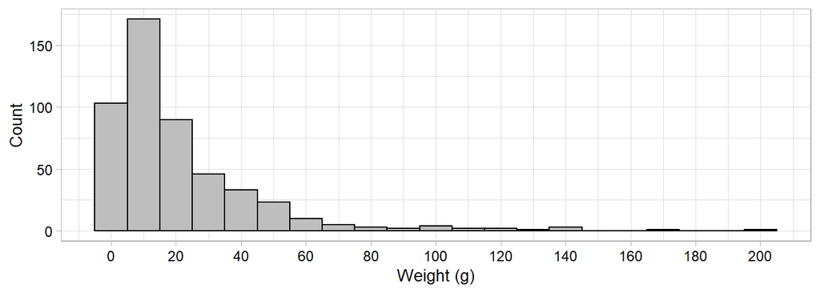

```r
# Histogram of flake weight
Reg_Data %>% ggplot(aes(Weight)) +
  geom_histogram(binwidth = 10,
                 color = "black", fill = "gray") +
  theme_light() +
  ylab("Count") +
  xlab("Weight (g)") +
  scale_x_continuous(breaks = seq(0, 200, 20)) +
  theme(
    axis.text = element_text(color = "black", size = 9),
    axis.title = element_text(color = "black", size = 10))
```

Collinearity between predictors has previously been reported for platform surface and platform depth, and mean thickness and log10 of maximum thickness (Bustos-Pérez and Baena, 2021). For the present dataset there is an important collinearity between log10 of maximum thickness and mean thickness ($r^2$ = 0.879); and an expected moderate/strong collinearity between platform depth and platform surface ($r^2$ = 0.614). Been aware of these collinearities is important since collinearity affects variable importance (hard to separate the individual effect of a variable on the response), it reduces the accuracy of the estimates on a Multiple Linear Regression, and it can result in counterintuitive estimates (James et al., 2013). Despite the challenges collinearity poses it is important to consider that collinearity does not affect predictions and the inferential power of the model (Alin, 2010; Paul, 2006). The maine focus of the present is the predictive accuracy of the models and not in the relations between predictors and dependent variable.

```r
# Collinearity between measures of thickness
R2(Reg_Data$MeanThick, Reg_Data$Log_Max_Thick)
```

```
## [1] 0.8791263
```

```r
# Collinearity between measures of platform
R2(Reg_Data$Platfom_Depth, Reg_Data$Surface.Plat)
```

```
## [1] 0.6140689
```

## 03 Model training and hyperparameter tunning

### 03.1 Multiple Linear regression

Multiple linear regression extends the simple linear regression to accommodate multiple predictors:

$$Y = \beta_0 + \beta_1X_1 + \beta_2X_2 +···\beta_pX_p + \epsilon$$

Althought Multiple Linear Regression is less prone to overfit the data it is still a good practice to performe multiple k-fold cross validation. As a standard the present research uses a 10 fold cross validation with 50 cycles.

```r
# Set Train control
train.control <- trainControl(method = "repeatedcv",
                              number = 10, repeats = 50,
                              savePredictions = TRUE)

# Train the model
frmla <- Log_Weight ~ MeanThick + Cortex + No_Scars + EPA + Log_Max_Thick + Log_Plat + Log_Plat_De

set.seed(123)
lm.model <- train(frmla,
               data = Reg_Data,
               method = "lm",
               trControl = train.control)
```

```r
summary(lm.model)
```

```
##
## Call:
## lm(formula = .outcome ~ ., data = dat)
##
## Residuals:
##      Min       1Q   Median       3Q      Max
## -0.69473 -0.13616  0.01939  0.13186  0.47859
##
## Coefficients:
##                 Estimate Std. Error t value Pr(>|t|)
## (Intercept)   -0.4427689  0.1301456  -3.402 0.000723 ***
## MeanThick      0.0337557  0.0064369   5.244 2.34e-07 ***
## Cortex        -0.0814959  0.0093836  -8.685  < 2e-16 ***
## No_Scars       0.0731414  0.0101348   7.217 2.03e-12 ***
## EPA            0.0017785  0.0009083   1.958 0.050805 .
## Log_Max_Thick  0.9273949  0.1430721   6.482 2.20e-10 ***
## Log_Plat       0.3358338  0.0469619   7.151 3.13e-12 ***
## Log_Plat_De   -0.3522401  0.0898045  -3.922 0.000100 ***
## ---
## Signif. codes:  0 '***' 0.001 '**' 0.01 '*' 0.05 '.' 0.1 ' ' 1
##
## Residual standard error: 0.2083 on 492 degrees of freedom
## Multiple R-squared:  0.779,  Adjusted R-squared:  0.7759
## F-statistic: 247.8 on 7 and 492 DF,  p-value: < 2.2e-16
```

### 03.2 Random Forest Regression

Random Forests build multiple decision trees from the training data (Breiman, 2001). Using different data adds diversity to the models. Predictiobs are obtained through the average of examples that reach a leaf. Finally, the results are averaged along all the grown trees.

Cartesian grid search is performed on the following hyperparameters: number of trees to grow for each model (ranging from 500 to 700 by 25); number of variables to possibly split at each node (ranging from 1 to 5); and minimal node size (ranging from 1 to 5).

Please note that while **mtry** (random number of variables to consider in each split) and **min.node.size** can be integrated into a cartesian grid search, the number of trees to grow cannot. Thus, it is necessary to include the training of the models in a loop were the number of trees changes in a sequence. At the end of each loop the best combination of mtry and min.node.size for the given number of trees is extracted (along with the results).

```r
#### Hyperparameter tuning for random forest ####
# range of hyperparameters
mtry <- seq(1, 5, 1)
min.node.size <- seq(1, 5, 1)
splitrule = "variance"

# Grid of possible combinations
hyper_grid <- expand.grid(
  mtry = mtry,
  min.node.size = min.node.size ,
  splitrule = "variance")

# Loop over different number of trees
best_tune <- data.frame(
  mtry = numeric(0),
  min_node.size = numeric(0),
  Num_Trees = numeric(0),
  r_squared = numeric(0))

my_seq <- seq(500, 700, 25)

set.seed(123)
for (x in my_seq){

  RF_weight <- train(frmla,
                       Reg_Data,
                       method = "ranger",
                       trControl = train.control,
                       num.trees = x,
                       tuneGrid = hyper_grid
  )

  Bst_R <- data.frame(
    mtry = RF_weight$bestTune[[1]],
    min_node.size = RF_weight$bestTune[[3]],
    Num_Trees = x,
    r_squared = RF_weight$finalModel[[10]])

  best_tune <- rbind(best_tune, Bst_R)

  Bst_R <- c()

}
```

The previous code is computationally expensive, but it ensures finding the best combination of hyperparameters. The following table presents the results of hyperparameter grid search.

```r
kable(best_tune)
```

| mtry | min_node.size | Num_Trees | r_squared |
| --- | --- | --- | --- |
| 2 | 5 | 500 | 0.7312673 |
| 2 | 5 | 525 | 0.7271587 |
| 2 | 5 | 550 | 0.7256057 |
| 2 | 5 | 575 | 0.7305429 |
| 2 | 4 | 600 | 0.7281003 |
| 2 | 4 | 625 | 0.7312961 |
| 2 | 5 | 650 | 0.7277806 |
| 2 | 5 | 675 | 0.7279673 |
| 2 | 4 | 700 | 0.7296423 |

On the table we can see that **mtry** is constant at a value of 2 for all combinations of number of trees and minimum node size. Additionally values of minimum node size range either from 4 or 5. This simplifies the visualization of hyperparameters.

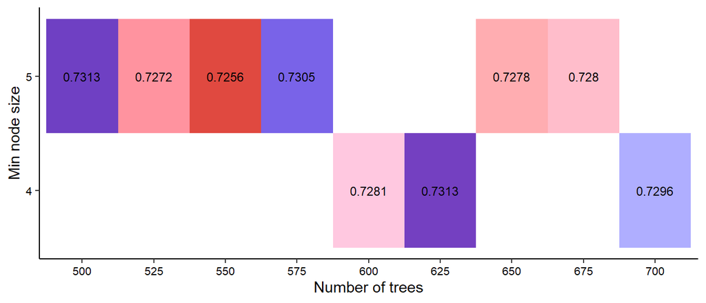

```r
#### Hyperparameters of Random forest ####
data.frame(best_tune) %>%
  ggplot(aes(factor(Num_Trees), min_node.size, fill = r_squared)) +
  geom_tile(alpha = 0.75) +
  xlab("Number of trees") +
  ylab("Min node size") +
  scale_y_continuous(breaks = seq(4, 5, 1), lim = c(3.5, 5.5)) +
  geom_text(aes(label = round(r_squared, 4)), size = 3) +
  ggsci::scale_fill_gsea(reverse = TRUE) +
  theme_classic() +
  theme(legend.position = "none",
        axis.text = element_text(color = "black", size = 8))
```

The following code returns the best combination of hyperparameters.

```r
best_tune_2 <- best_tune[which.max(best_tune$r_squared),]
best_tune_2
```

```
##   mtry min_node.size Num_Trees r_squared
## 6    2             4       625 0.7312961
```

Finally, the Random forest with optimal combination of hyperparameters can be trained.

```r
#### Final random forest model ####
newr_grid <- expand.grid(mtry = best_tune_2$mtry,
                          min.node.size = best_tune_2$min_node.size,
                          splitrule = "variance"
)

RF_weight <- train(frmla,
                   Reg_Data,
                   method = "ranger",
                   trControl = train.control,
                   tuneGrid = newr_grid,
                   num.trees = best_tune$Num_Trees,
                   importance = "impurity_corrected")
```

### 03.3 Artificial Neuronal Network (ANN)

Artificial Neuronal Networks (ANN) model the relationship between input data and the output signal through a series of hidden layers each composed by a number of nodes (Lantz, 2015). The present work uses the R package “neuralnet” (Günther and Fritsch, 2010) to train ANN with backpropagation (Rumelhart et al., 1986). For the present work ANN topology is limited to having only one or two hidden layers. Number of nodes of hidden layer 1 ranges between 1 and 4 while number of nodes of hidden layer 2 ranges from 0 (no second hidden layer) to 4. All possible combination are tested.

```r
#### Look for best ANN architecture ####
 set.seed(123)
 train.control <- trainControl(method = "repeatedcv",
                               number = 10, repeats = 50,
                               verboseIter = TRUE)

  tune.grid.neuralnet <- expand.grid(
   .layer1 = c(1:4),
   .layer2 = c(0:4),
   .layer3 = 0
 )

 nnet_model <- train(
   Log_Weight ~ MeanThick + Log_Max_Thick + EPA + Log_Plat + Log_Plat_De + Cortex + No_Scars,
   Reg_Data,
   method = 'neuralnet',
   trControl = train.control,
   tuneGrid = tune.grid.neuralnet,
   preProcess = c("center", "scale"),
   learningrate = 0.01,
   threshold = 0.01,
   stepmax = (10^100),
   linear.output = TRUE
 )
```

Cartesian grid search of ANN topology indicates that increasing the number of nodes in the first hidden layer decreases linear correlation with the outcome. On general Cartesian grid search of ANN topology indicates that increasing the number of layers and nodes results in lower values of $r^2$. Thus, the most simple ANN architecture (one hidden layer with one node) provides the highest correlation coefficient ($r^2$ = 0.78). The second best topology (two hidden layers with one node at each layer) provides a marginally lower value (0.0005 lower).

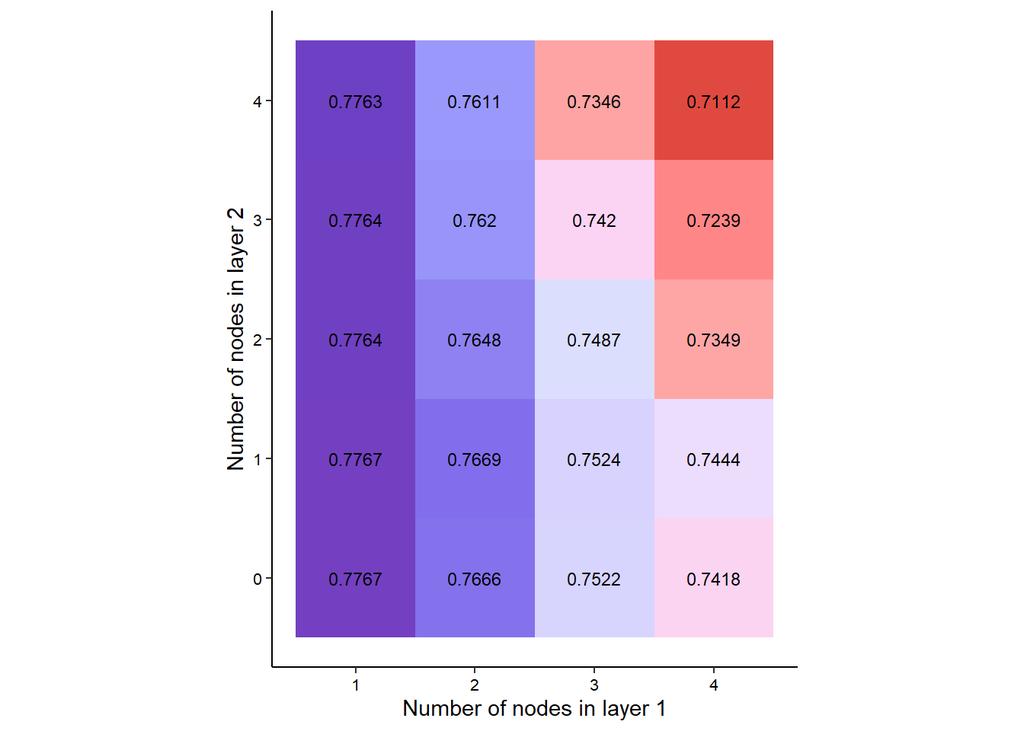

```r
data.frame(nnet_model$results) %>%
  ggplot(aes(layer1, layer2, fill = Rsquared)) +
  geom_tile(alpha = 0.75) +
  geom_text(aes(label = round(Rsquared, 4)), size = 3) +
  ggsci::scale_fill_gsea(reverse = TRUE) +
  xlab("Number of nodes in layer 1") +
  ylab("Number of nodes in layer 2") +
  theme_classic() +
  coord_fixed() +
  theme(legend.position = "none",
        axis.text = element_text(color = "black", size = 8))
```

## 04 Results

### 04.1 Model evaluation metrics

```r
Temp <- data.frame(rbind(
  round(MLR_model$results[2:4],2),
  round(nnet_model_f$results[4:6],2),
  round(RF_model$results[4:6],2)))

Temp <- cbind(data.frame(model = c("MLR", "ANN", "RF")), Temp)

kable(Temp)
```

| model | RMSE | Rsquared | MAE |
| --- | --- | --- | --- |
| MLR | 0.21 | 0.78 | 0.17 |
| ANN | 0.21 | 0.78 | 0.17 |
| RF | 0.24 | 0.72 | 0.19 |

Visualization of regression plots for each model provides additional information of the performance of each model. The poor performance of Random Forest (lowest value of $r^2$) is reflected in a limited range of prediction. The prediction range of the Random Forest is limited between a minimum value of 0.55 and a maximum value of 1.76 for log10 of flake mass. As a result of this, data is not evenly distributed among the regression line. In the lowest values of prediction most points fall below the regression line while most data points falling above for the highest values of the regression line. ANN and multiple linear regression plots present similar patterns of distribution with data evenly distributed among the regression line. Flakes with a log10 value of flake mass above 2 are lightly more evenly distributed for the multiple linear regression than for the ANN.

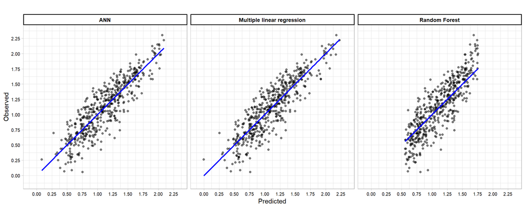

```r
#### Linear model ####
MLR_results <- as.data.frame(MLR_model$pred) %>%
  group_by(rowIndex) %>%
  summarise(Pred = mean(pred),
            Obs = mean(obs)) %>%
  mutate(Residual = Obs - Pred)

#### ANN model ####
nnet_results <- as.data.frame(nnet_model_f$pred) %>%
  group_by(rowIndex) %>%
  summarise(Pred = mean(pred),
            Obs = mean(obs)) %>%
  mutate(Residual = Obs - Pred)

#### RF Model ####
RF_results <- as.data.frame(RF_model$pred) %>%
  group_by(rowIndex) %>%
  summarise(Pred = mean(pred),
            Obs = mean(obs)) %>%
  mutate(Residual = Obs - Pred)

#### Put models together #####
Temp <- rbind(MLR_results, nnet_results, RF_results)
Temp$Model <- "Multiple linear regression"
Temp$Model[501:1000] <- "ANN"
Temp$Model[1001:1500] <- "Random Forest"

#### Correlation plot ####
Temp %>%
  ggplot(aes(Pred, Obs)) +
  geom_point(alpha = 0.5, size = 1.5) +
  geom_line(aes(y = Pred), size = 1, col = "blue") +

  scale_x_continuous(breaks = seq(0, 2.55, 0.25), lim = c(-0.1, 2.35)) +
  scale_y_continuous(breaks = seq(0, 2.55, 0.25), lim = c(-0.1, 2.35)) +

  xlab("Predicted") +
  ylab("Observed") +

  facet_wrap(~ Model, ncol = 3) +
  coord_fixed() +
  theme_light() +
  theme(strip.text = element_text(color = "black", face = "bold", size = 9),
        strip.background = element_rect(fill = "white", colour = "black", size = 1),
        axis.text = element_text(size = 7.5, color = "black"))
```

### 04.2 Residuals analysis and distribution

Visual analysis of the scatter plot for observed and residual values allows to observe model performance for different ranges of log10 of flake mass values. Residuals of the Random Forest present a systematic bias for the upper and lowest values of observed weight. In the case of flakes with a log10 value of 0.50 there is a systematic overestimation of the size. In the case of flakes with a log10 value of 1.75 there is a systematic underestimation of values. ANN and multiple linear regression present very similar plots for observed values and residuals. In both cases residual values indicate a systematic overestimation of a log10 flake mass when the actual value is below 0.25.  
Between values of 0.25 and 2 both models present a very similar performance with residual values falling evenly among the 0 value. ANN seems to present a slightly systematic underestimation of flakes with a log10 of flake mass above a value of 2. Multiple linear regression does seem to perform better for flakes with a log10 flake mass value above 2 with residual values falling evenly or very close to the 0 value line.

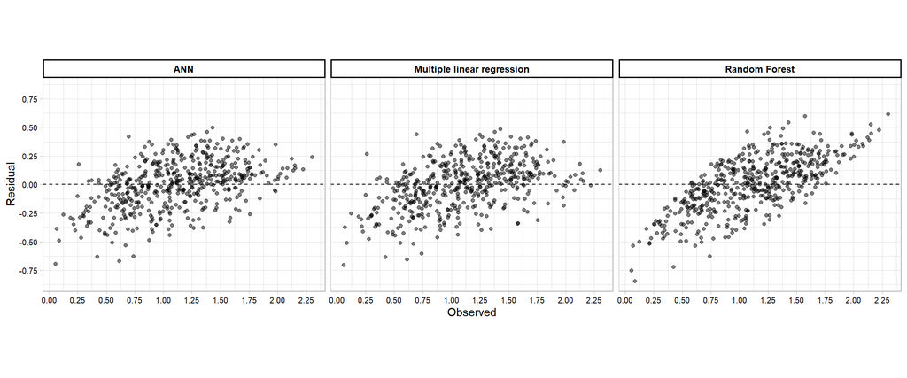

```r
## Plots of observed values and residuals
Temp %>%
  ggplot(aes(Obs, Residual)) +
  geom_point(alpha = 0.5, size = 1.5) +

  xlab("Observed") +
  ylab("Residual") +

  scale_x_continuous(breaks = seq(0, 2.55, 0.25), lim = c(min(Temp$Obs), max(Temp$Obs))) +
  scale_y_continuous(breaks = seq(-0.75, 0.75, 0.25), lim = c(-0.85, 0.85)) +
  geom_hline(yintercept = 0, linetype = "dashed") +

  facet_wrap(~ Model, ncol = 3) +
  coord_fixed() +
  theme_light() +
  theme(strip.text = element_text(color = "black", face = "bold", size = 9),
        strip.background = element_rect(fill = "white", colour = "black", size = 1),
        axis.text = element_text(size = 7.5, color = "black"))
```

Correlation between observed values and residuals allows to evaluate if residuals increase along with increasing values of log10 of weight. ANN and multiple linear regression models present the same value of $r^2$ for correlation of observed values and residuals ($r^2$ = 0.22; p < 0.01) while Random Forest presents a higher value of correlation ($r^2$ = 0.5; p < 0.01).

```r
# Residuals and multiple linear regression
summary(lm(Residual ~ Obs, MLR_results))
```

```
##
## Call:
## lm(formula = Residual ~ Obs, data = MLR_results)
##
## Residuals:
##      Min       1Q   Median       3Q      Max
## -0.54486 -0.11287  0.00723  0.12352  0.53357
##
## Coefficients:
##             Estimate Std. Error t value Pr(>|t|)
## (Intercept) -0.24837    0.02260  -10.99   <2e-16 ***
## Obs          0.22306    0.01889   11.81   <2e-16 ***
## ---
## Signif. codes:  0 '***' 0.001 '**' 0.01 '*' 0.05 '.' 0.1 ' ' 1
##
## Residual standard error: 0.1857 on 498 degrees of freedom
## Multiple R-squared:  0.2188, Adjusted R-squared:  0.2172
## F-statistic: 139.4 on 1 and 498 DF,  p-value: < 2.2e-16
```

```r
# Residuals and ANN
summary(lm(Residual ~ Obs, nnet_results))
```

```
##
## Call:
## lm(formula = Residual ~ Obs, data = nnet_results)
##
## Residuals:
##      Min       1Q   Median       3Q      Max
## -0.55719 -0.10717 -0.00036  0.13051  0.51214
##
## Coefficients:
##             Estimate Std. Error t value Pr(>|t|)
## (Intercept) -0.24798    0.02258  -10.98   <2e-16 ***
## Obs          0.22286    0.01887   11.81   <2e-16 ***
## ---
## Signif. codes:  0 '***' 0.001 '**' 0.01 '*' 0.05 '.' 0.1 ' ' 1
##
## Residual standard error: 0.1855 on 498 degrees of freedom
## Multiple R-squared:  0.2188, Adjusted R-squared:  0.2172
## F-statistic: 139.5 on 1 and 498 DF,  p-value: < 2.2e-16
```

```r
# Residuals and RF model
summary(lm(Residual ~ Obs, RF_results))
```

```
##
## Call:
## lm(formula = Residual ~ Obs, data = RF_results)
##
## Residuals:
##      Min       1Q   Median       3Q      Max
## -0.49052 -0.11216  0.00151  0.10916  0.47628
##
## Coefficients:
##             Estimate Std. Error t value Pr(>|t|)
## (Intercept) -0.42164    0.02052  -20.55   <2e-16 ***
## Obs          0.38224    0.01715   22.29   <2e-16 ***
## ---
## Signif. codes:  0 '***' 0.001 '**' 0.01 '*' 0.05 '.' 0.1 ' ' 1
##
## Residual standard error: 0.1686 on 498 degrees of freedom
## Multiple R-squared:  0.4994, Adjusted R-squared:  0.4984
## F-statistic: 496.8 on 1 and 498 DF,  p-value: < 2.2e-16
```

Descriptive statistics of residuals and density plots allow to evaluate dispersion range of residuals. All models present average and median residual values close to 0 with density curves peaking near this value which is indicative of a good model performance. 50% of residual values from ANN model fall between values of -0.133 and 0.143 making for a distance of 0.276. 50% of residual values from multiple linear regression model fall between values of -0.137 and 0.134 making for a distance of 0.271. 50% of residual values from multiple Random Forest model fall between values of -0.138 and 0.177 making for a distance of 0.315. This indicates that multiple linear regression model concentrates 50% of residuals values in a slightly shorter range. This range is 0.005 shorter than the one from ANN model. The Random forest presents the highest dispersion range for 50% of residual values.

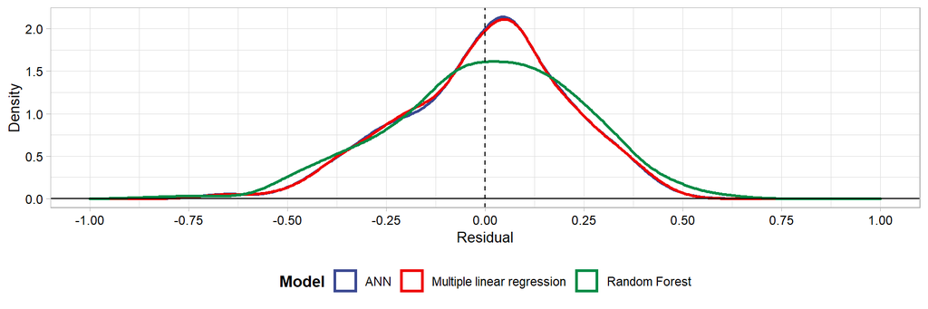

```r
# Density plot of residuals
Temp %>% ggplot(aes(Residual, color = Model)) +
  geom_density(size = 1) +
  ggsci::scale_color_aaas() +
  scale_x_continuous(breaks = seq(-1, 1, 0.25), lim = c(-1,1)) +
  geom_vline(xintercept = 0, linetype = "dashed") +
  geom_hline(yintercept = 0) +
  ylab("Density") +
  theme_light() +
  theme(legend.position = "bottom",
        legend.title = element_text(face = "bold"),
        axis.text = element_text(color = "black", size = 9),
        axis.title = element_text(color = "black", size = 10))
```

90% of residual values from ANN model fall between values of -0.379 and 0.33 making for a distance of 0.709. 90% of residual values from multiple linear regression model fall between values of -0.371 and 0.333 making for a distance of 0.704. 90% of residual values from Random Forest model fall between values of -0.412 and 0.355 making for a distance of 0.767. Again, multiple linear regression concentrates 90% of residuals in the shortest range. ANN presents a slightly wider range (difference of 0.005) and Random Forest presents the widest range of the three models.

```r
kable(
  Temp %>% group_by(Model) %>%
  summarise(
    Min = min(Residual),
    `5 Percentil` = quantile(Residual, 0.05),
    `1Quantile` = quantile(Residual, 0.25),
    Mean = mean(Residual),
    Median = quantile(Residual, 0.5),
    `3Quantile` = quantile(Residual, 0.75),
    `95 Percentil` = quantile(Residual, 0.95),
    Max = max(Residual)
  ))
```

| Model | Min | 5 Percentil | 1Quantile | Mean | Median | 3Quantile | 95 Percentil | Max |
| --- | --- | --- | --- | --- | --- | --- | --- | --- |
| ANN | -0.6952028 | -0.3790468 | -0.1331217 | 0.0000595 | 0.0240733 | 0.1428723 | 0.3295823 | 0.4993439 |
| Multiple linear regression | -0.7046012 | -0.3711780 | -0.1368752 | -0.0001095 | 0.0204098 | 0.1341937 | 0.3332873 | 0.4823185 |
| Random Forest | -0.8456258 | -0.4117285 | -0.1383524 | 0.0037893 | 0.0133008 | 0.1773731 | 0.3550391 | 0.6154902 |

```r
# Order of flakes is kept the same for all models
Terminations <- Reg_Data %>% select(Termination_type)
Terminations <- rbind(Terminations, Terminations, Terminations)
Terminations <- cbind(Temp, Terminations)

# Mutate to new categories: feather termination and other types of terminations
Terminations <- Terminations %>% mutate(
  New_Term =
  case_when(
    Termination_type == "Feather" ~ "Feather",
    Termination_type != "Feather" ~ "Other"))
```

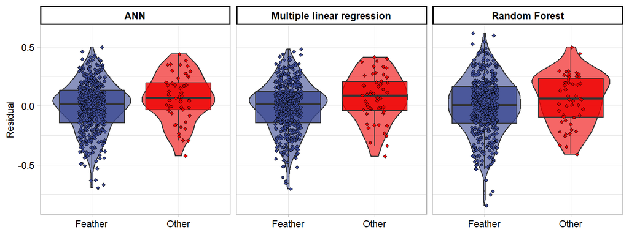

```r
Terminations %>%
  ggplot(aes(New_Term, Residual, fill = New_Term)) +
  facet_wrap(~ Model, ncol = 3) +
  geom_violin(alpha = 0.6) +
  geom_boxplot(alpha = 0.8, outlier.size = 0) +
  geom_jitter(width = 0.15, alpha = 1, size = 0.9, shape = 23, aes(fill = New_Term)) +
  ggsci::scale_fill_aaas() +
  xlab(NULL) +
  theme_light() +
  theme(
    legend.position = "none",
    strip.text = element_text(color = "black", face = "bold", size = 9),
    strip.background = element_rect(fill = "white", colour = "black", size = 1),
    axis.text = element_text(color = "black", size = 8.5),
    axis.title = element_text(color = "black", size = 9))
```

Exploratory data analysis of residuals according to termination type through box and violin plots shows possible differences in the distribution for the three models. Comparison of residuals means according to termination type and for each model through t-test shows significant differences for the ANN model (t = -2.5; p = 0.02), the multiple linear regression (t = -2.52; p = 0.01), but not for the random forest regression (t = -1.82, p = 0.07). In all models residuals mean of flakes with feather terminations fall near the cero value (-0.007 in the case of ANN; -0.008 in the case of multiple linear regression and -0.002 in the case of Random Forest). Flakes with other termination than feather tend to have a slightly higher mean of residuals values (0.07 in the case of ANN; 0.07 in the case of multiple linear regression; 0.06 in the case of random Forest).

```r
# t-test residuals and terminations for ANN
t.test(Residual ~ New_Term, data = Terminations[Terminations$Model == "ANN",])
```

```
##
##  Welch Two Sample t-test
##
## data:  Residual by New_Term
## t = -2.4964, df = 63.439, p-value = 0.01516
## alternative hypothesis: true difference in means between group Feather and group Other is not equal to 0
## 95 percent confidence interval:
##  -0.13238703 -0.01467883
## sample estimates:
## mean in group Feather   mean in group Other
##           -0.00744086            0.06609207
```

```r
# t-test residuals and terminations for Multiple linear regression
t.test(Residual ~ New_Term, data = Terminations[Terminations$Model == "Multiple linear regression",])
```

```
##
##  Welch Two Sample t-test
##
## data:  Residual by New_Term
## t = -2.5239, df = 62.665, p-value = 0.01416
## alternative hypothesis: true difference in means between group Feather and group Other is not equal to 0
## 95 percent confidence interval:
##  -0.13631906 -0.01583418
## sample estimates:
## mean in group Feather   mean in group Other
##          -0.007869329           0.068207291
```

```r
# t-test residuals and terminations for Random Forest
t.test(Residual ~ New_Term, data = Terminations[Terminations$Model == "Random Forest",])
```

```
##
##  Welch Two Sample t-test
##
## data:  Residual by New_Term
## t = -1.8155, df = 65.4, p-value = 0.07403
## alternative hypothesis: true difference in means between group Feather and group Other is not equal to 0
## 95 percent confidence interval:
##  -0.121451961  0.005779731
## sample estimates:
## mean in group Feather   mean in group Other
##          -0.002109984           0.055726131
```

### 04.2 Variable importance

The following presents variable relative importance scaled from 0 to 100 for each model. ANN considers of key importance variables of thickness (mean thickness of the flake and log10 of flake thickness) along with log10 of platform size. Relative amount of cortex is also considered to have relative importance. Multiple linear regression considers relative amount of cortex, number of scars and log10 of platform size as the most important variables. Log10 of maximum thickness is also considered as an important variable. Random Forest only considers mean thickness and log10 of maximum thickness as important variables.

Only ANN model provides an importance value above 0 for EPA, although it is considered as the least important variable for that model. On general log10 of platform size is considered as an important variable being the third most important variable for multiple linear regression and Random Forest; and the second most important variable for ANN. Log10 of platform depth is usually considered a minor important variable by all models with scores of importance below the 50 value threshold.

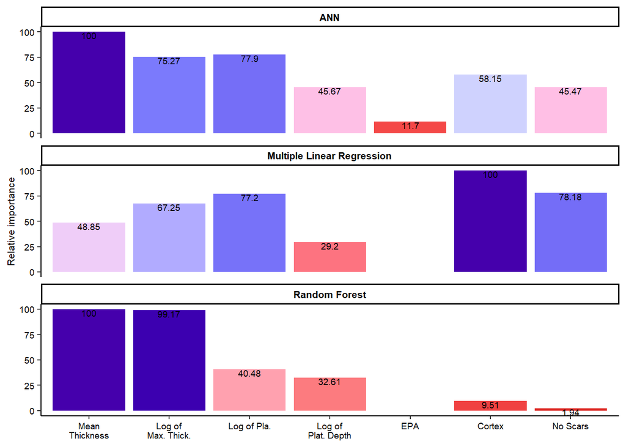

```r
#### Variable importance ####
# Make Data frame of importance of MLR
mr_imp <- varImp(MLR_model, scale = TRUE)
mr_imp <- as.data.frame(mr_imp$importance)
mr_imp$Variable = rownames(mr_imp)
mr_imp$Model = "Multiple Linear Regression"

# Make Data frame of importance of ANN
temp <- NeuralNetTools::garson(nnet_model_f)

ANN_imp <- data.frame(temp$data) %>% mutate(
  Overall = (rel_imp*100)/0.24145208) %>%
  select(-c(rel_imp)) %>%
  rename(Variable = x_names) %>%
  mutate(Model = "ANN") %>%
  select(Overall, Variable, Model)

# Make Data frame of RF importance
RF_imp <- varImp(RF_model, scale = TRUE)
RF_imp <- as.data.frame(RF_imp$importance)
RF_imp$Variable = rownames(RF_imp)
RF_imp$Model = "Random Forest"

#### Variable importance according to model
Var_Imp <- rbind(mr_imp, ANN_imp, RF_imp)
rm(mr_imp, ANN_imp, RF_imp)

# reset variable labels
Var_Imp$Variable <- factor(Var_Imp$Variable,
                           levels = c("MeanThick", "Log_Max_Thick",
                                      "Log_Plat", "Log_Plat_De",
                                      "EPA", "Cortex", "No_Scars"),
                           labels = c("Mean\nThickness", "Log of\nMax. Thick.",
                                      "Log of Pla.", "Log of\nPlat. Depth",
                                    "EPA", "Cortex",
                                    "No Scars"))

# and plot
Var_Imp %>% ggplot(aes(Variable, Overall, fill = Overall)) +
  geom_col() +
  geom_text(data = Var_Imp[Var_Imp$Overall > 0,],
            aes(label = round(Overall, 2)), vjust= "top", size = 2.5) +
  ggsci::scale_fill_gsea(reverse = TRUE) +
  theme_classic() +
  facet_wrap(~ Model, ncol = 1) +
  ylab("Relative importance") +
  xlab(NULL) +
  theme(legend.position = "none",
        axis.text = element_text(color = "black", size = 7),
        strip.text = element_text(color = "black", face = "bold", size = 8),
        strip.background = element_rect(fill = "white", colour = "black", size=1),
        axis.title.y = element_text(color = "black", size = 8))
```

### 04.4 Linear transformation of predictions

```r
# Transform into linear scale
Temp <- Temp %>%
  mutate(Observed = 10^Obs,
         Predicted = 10^Pred,
         Line_Res = Observed - Predicted)
```

```r
ANN <- Temp %>% filter(Model == "ANN")
MLR <- Temp %>% filter(Model == "Multiple linear regression")
RF <- Temp %>% filter(Model == "Random Forest")

# Performance metrics
kable(data.frame(
  "Metric" =
    c("r2", "RMSE", "MAE"),

  "ANN" =
    c(round(R2(ANN$Observed, ANN$Predicted),3),
  round(RMSE(ANN$Observed, ANN$Predicted),3),
  round(MAE(ANN$Observed, ANN$Predicted), 3)),

  "Mult. Linear Reg." =
    c(round(R2(MLR$Observed, MLR$Predicted),3),
    round(RMSE(MLR$Observed, MLR$Predicted),3),
    round(MAE(MLR$Observed, MLR$Predicted), 3)),

  "Random Forest" =
    c(round(R2(RF$Observed, RF$Predicted),3),
    round(RMSE(RF$Observed, RF$Predicted),3),
    round(MAE(RF$Observed, RF$Predicted), 3))
))
```

| Metric | ANN | Mult..Linear.Reg. | Random.Forest |
| --- | --- | --- | --- |
| r2 | 0.801 | 0.814 | 0.660 |
| RMSE | 11.344 | 10.853 | 16.996 |
| MAE | 6.942 | 6.793 | 8.700 |

Visualization of regression plots also supports the better generalization of multiple linear regression to the linear scale. Random Forest limits its maximum prediction to 57.2 g resulting in a poor generalization to the linear scale. Due to this, residuals from the Random Forest indicate important underestimations of flake weight with an average underestimation of 4.6 g. 50% of the residuals of the Random Forest range between overestimations of 2.64 g and underestimations of 7.06 g. 90% of the residuals from the random forest range between overestimations of 10.35 g and underestimations of 29.74 g.

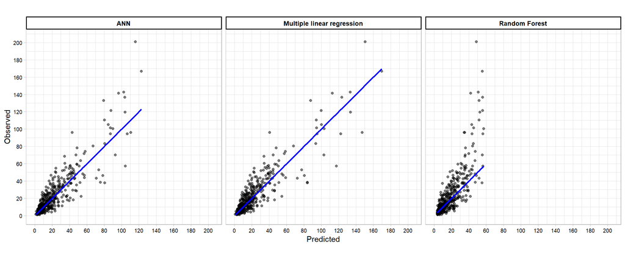

```r
## Regression plot on linear scale
Temp %>% ggplot(aes(Predicted, Observed)) +
  geom_point(alpha = 0.5, size = 1.5) +
  geom_line(aes(y = Predicted), size = 1, col = "blue") +

  scale_x_continuous(breaks = seq(0, 205, 20), lim = c(0, 205)) +
  scale_y_continuous(breaks = seq(0, 205, 20), lim = c(0, 205)) +

  facet_wrap(~ Model) +
  coord_fixed() +
  theme_light() +
  theme(strip.text = element_text(color = "black", face = "bold", size = 9),
        strip.background = element_rect(fill = "white", colour = "black", size = 1),
        axis.text = element_text(size = 7.5, color = "black"))
```

Visual representation of residuals of the Random Forest through density plot shows that despite peaking on the 0 value it presents a long tale of positive residuals as a result of underestimations of predictions.

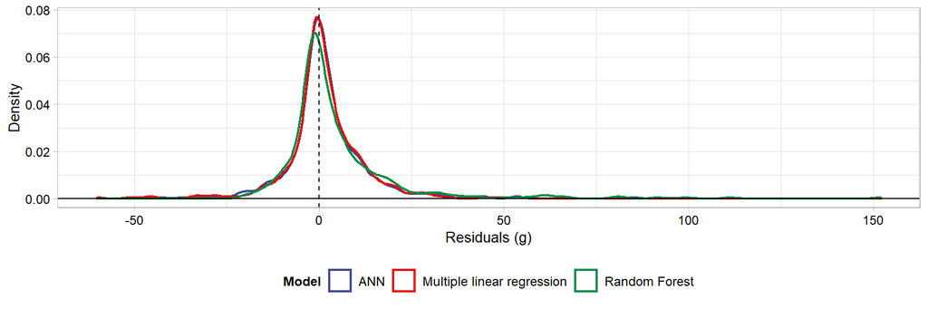

```r
#  Density plot of residuals in the linear scale
Temp %>% ggplot(aes(Line_Res, color = Model)) +
  geom_density(size = 0.75) +
  ggsci::scale_color_aaas() +
  geom_vline(xintercept = 0, linetype = "dashed") +
  geom_hline(yintercept = 0) +
  ylab("Density") +
  xlab("Residuals (g)") +
  theme_light() +
  theme(legend.position = "bottom",
        legend.title = element_text(face = "bold",size = 9),
        axis.text = element_text(color = "black", size = 9),
        axis.title = element_text(color = "black", size = 10),
        legend.text = element_text(size = 9))
```

```r
# Descriptive statistics of residuals in the linear scale

kable(Temp %>% group_by(Model) %>%
  summarise(
    Min = min(Line_Res),
    `5 Percentil` = quantile(Line_Res, 0.05),
    `1Quantile` = quantile(Line_Res, 0.25),
    Mean = mean(Line_Res),
    Median = quantile(Line_Res, 0.5),
    `3Quantile` = quantile(Line_Res, 0.75),
    `95 Percentil` = quantile(Line_Res, 0.95),
    Max = max(Line_Res)
  ))
```

| Model | Min | 5 Percentil | 1Quantile | Mean | Median | 3Quantile | 95 Percentil | Max |
| --- | --- | --- | --- | --- | --- | --- | --- | --- |
| ANN | -47.08316 | -13.79028 | -2.516174 | 1.816030 | 0.4762883 | 5.552758 | 19.80933 | 84.98876 |
| Multiple linear regression | -60.22261 | -13.18240 | -2.422225 | 1.400462 | 0.3307878 | 5.724842 | 18.79086 | 55.58517 |
| Random Forest | -20.06615 | -10.35089 | -2.641137 | 4.611775 | 0.3338027 | 7.059517 | 29.74203 | 152.07560 |

## 05 References

Alin, A., 2010. Multicollinearity. Wiley Interdisciplinary Reviews: Computational Statistics 2, 370–374.

Bagolini, B., 1968. Ricerche sulle dimensioni dei manufatti litici preistorici non ritoccati. Annali dell’Università di Ferrara : nuova serie, Sezione XV. Paleontologia Umana e Paletnologia 1, 195–219.

Breiman, L., 2001. Random Forests. Machine Learning 45, 5–32. https://doi.org/10.1023/A:1010933404324

Bustos-Pérez, G., Baena, J., 2021. Predicting Flake Mass: A View from Machine Learning. Lithic Technology 46, 130–142. https://doi.org/10.1080/01977261.2021.1881267

Günther, F., Fritsch, S., 2010. Neuralnet: training of neural networks. The R Journal 2, 30–38.

Heil, B.J., Hoffman, M.M., Markowetz, F., Lee, S.-I., Greene, C.S., Hicks, S.C., 2021. Reproducibility standards for machine learning in the life sciences. Nature Methods 18, 1132–1135.

James, G., Witten, D., Hastie, T., Tibshirani, R., 2013. An Introduction to Statistical Learning with Applications in R, Second Edition. ed. Springer.

Kuhn, M., 2008. Building Predictive Models in R using the caret Package. Journal of Statistical Software 28. https://doi.org/10.18637/jss.v028.i05

Paul, R.K., 2006. Multicollinearity: Causes, effects and remedies. IASRI, New Delhi 1, 58–65.

Rumelhart, D.E., Hinton, G.E., Williams, R.J., 1986. Learning representations by back-propagating errors. Nature 323, 533–536.

Wickham, H., Averick, M., Bryan, J., Chang, W., McGowan, L., François, R., Grolemund, G., Hayes, A., Henry, L., Hester, J., Kuhn, M., Pedersen, T., Miller, E., Bache, S., Müller, K., Ooms, J., Robinson, D., Seidel, D., Spinu, V., Takahashi, K., Vaughan, D., Wilke, C., Woo, K., Yutani, H., 2019. Welcome to the Tidyverse. JOSS 4, 1686. https://doi.org/10.21105/joss.01686

Andrefsky, W., 2009. The analysis of stone tool procurement, production, and maintenance. Journal of Archaeological Research 17, 65–103. https://doi.org/10.1007/s10814-008-9026-2

Binford, L.R., 1979. Organization and formation processes: Looking at curated technologies. Journal of Anthropological Research 35, 255–273.

Binford, L.R., 1973. Interassemblage variability - the mousterian and the ’functional ’ argument, in: Renfrew, C. (Ed.), The Explanation of Culture Change. Models in Prehistory. Duckworth, Gloucester, pp. 227–254.

Nelson, M.C., 1991. The study of technological organization. Archaeological Method and Theory 57–100.

Spry, C., Stern, N., 2016. Technological organization, in: Jackson, J.L. (Ed.), Oxford Bibliographies in “Anthropology.” Oxford University Press, New York.